# Florence_analysis

# Analysis- Local Spatial autocorrelation

Let’s now investigate the Local spatial auto-correlation using the Moran’s I Scatterplot

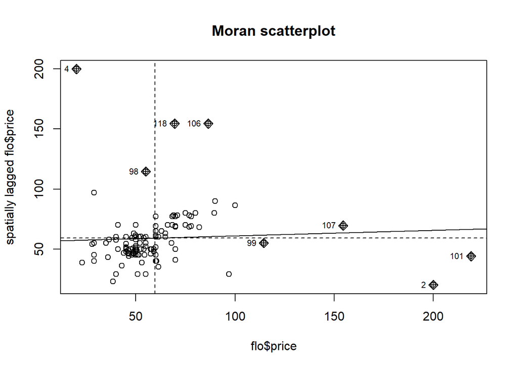

```r
mplot <- moran.plot(flo$price, listw=sp_w1, main="Moran scatterplot",
                    return_df=F)
```

```r
hotspot <- as.numeric(row.names(as.data.frame(summary(mplot))))
```

```
## Potentially influential observations of
##   lm(formula = wx ~ x) :
##
##     dfb.1_  dfb.x   dffit   cov.r   cook.d  hat
## 2    1.03_* -1.24_* -1.26_*  1.23_*  0.77_*  0.24_*
## 4    1.20_* -1.01_*  1.22_*  0.49_*  0.51    0.03
## 98   0.12   -0.04    0.22    0.93_*  0.02    0.01
## 99   0.04   -0.05   -0.06    1.06_*  0.00    0.04
## 101  0.63   -0.75   -0.76_*  1.43_*  0.29    0.31_*
## 106 -0.20    0.40    0.56_*  0.77_*  0.14    0.02
## 107 -0.07    0.09    0.10    1.15_*  0.00    0.11_*
## 118  0.03    0.15    0.42_*  0.76_*  0.08    0.01
```

```r
flo$wx <- lag.listw(sp_w1, flo$price)

flo$quadrant <- rep("None", length(flo$price))
for(i in 1:length(hotspot))  {
  if (flo$price[hotspot[i]]>mean(flo$price) & flo$wx[hotspot[i]]> mean(flo$wx))
    flo$quadrant[hotspot[i]] <- "HH"
  if (flo$price[hotspot[i]]>mean(flo$price) & flo$wx[hotspot[i]]< mean(flo$wx))
    flo$quadrant[hotspot[i]] <- "HL"
  if (flo$price[hotspot[i]]<mean(flo$price) & flo$wx[hotspot[i]]<mean(flo$wx))
    flo$quadrant[hotspot[i]] <- "LL"
  if (flo$price[hotspot[i]]<mean(flo$price) & flo$wx[hotspot[i]]>mean(flo$wx))
    flo$quadrant[hotspot[i]] <- "LH"
}
table(flo$quadrant)
```

```
##
##   HH   HL   LH None
##    3    3    2  113
```

The marked points are the points that influence more the slope of this regression line. The slope is quite low, as expected from the previous global analysis.

Let’s try to map regions with noteworthy influence coded by their quadrant in the Moran scatterplot. In this way, we can identify the regions that have contributed more to the form of spatial auto-correlation.

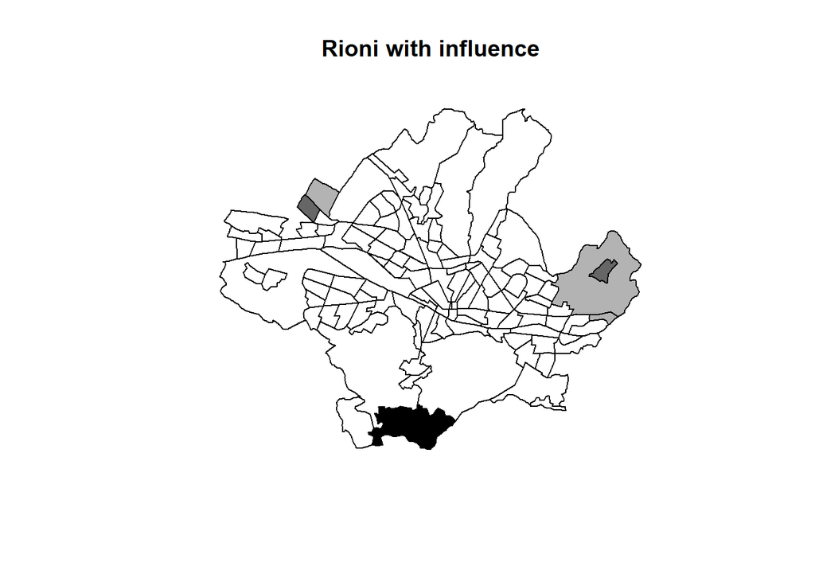

```r
flo$colours[flo$quadrant=="None"] <- "white"
flo$colours[flo$quadrant=="HH"] <- "black"
flo$colours[flo$quadrant=="LL"] <- gray(0.9)
flo$colours[flo$quadrant=="LH"] <- gray(0.4)
flo$colours[flo$quadrant=="HL"] <- gray(0.7)
plot(flo, col=flo$colours);legend(x=-10, y=73, legend=c("None", "Low-Low", "High-Low", "Low-High", "High-High"),
       fill=c("white", gray(0.9), gray(0.7), gray(0.4),
              "black"), bty="n", cex=0.8);title(main="Rioni with influence")
```

```r
###
lmI <- localmoran(flo$price,sp_w1)
head(lmI)
```

```
##            Ii         E.Ii   Var.Ii        Z.Ii Pr(z > 0)
## 1  0.05370713 -0.008333333 0.850638  0.06726708 0.4731845
## 2 -7.87163608 -0.008333333 0.850638 -8.52575024 1.0000000
## 3  1.09587398 -0.008333333 0.850638  1.19723176 0.1156081
## 4 -7.87163608 -0.008333333 0.850638 -8.52575024 1.0000000
## 5  0.55655354 -0.008333333 0.850638  0.61247602 0.2701114
## 6  1.09587398 -0.008333333 0.850638  1.19723176 0.1156081
```

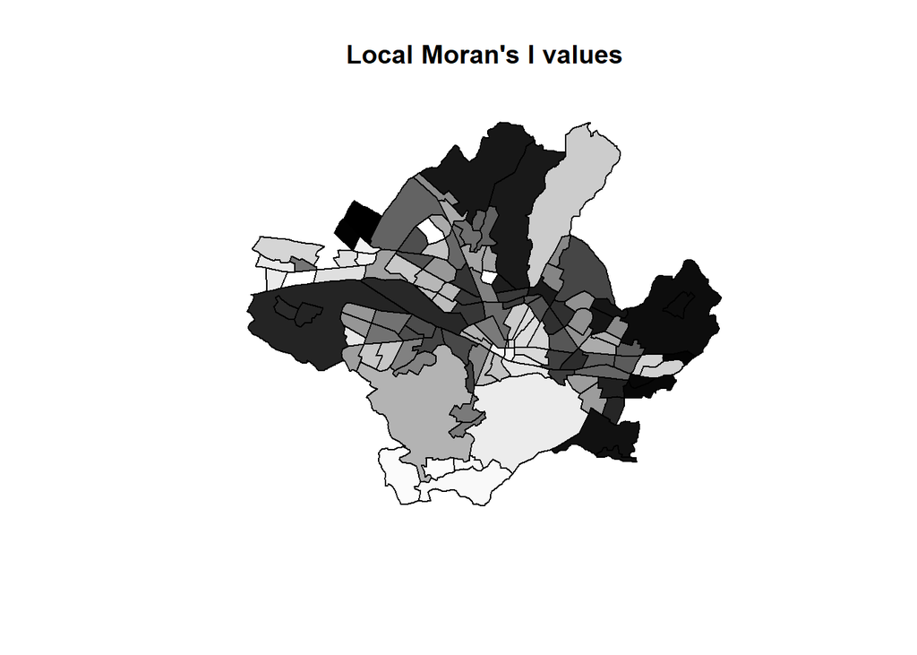

```r
brks <- sort(as.numeric(lmI[,1]))
colours <- grey((0:length(lmI[,1]))/length(lmI[,1]))
plot(flo, col=colours[findInterval(lmI[,1], brks, all.inside=TRUE)]);title(main="Local Moran's I values")
```

This plot may suggest that there are some local clusters, but to assess the significance of the revealed pattern I need to use the *Local Moran’s Index*.

What I expect from the following plot?

Well, since the Local Moran’s I is a local measure of spatial auto-correlation, that I computed for each single spatial unit and that it is the composition of the global Moran’s I across all the spatial units. If we compute the average of all the values of the Local Moran’s I across all the spatial units, I obtain the global Moran’s I.

Hence, given that the global Moran’I was almost 0, I expect that most of the spatial units will be blank.

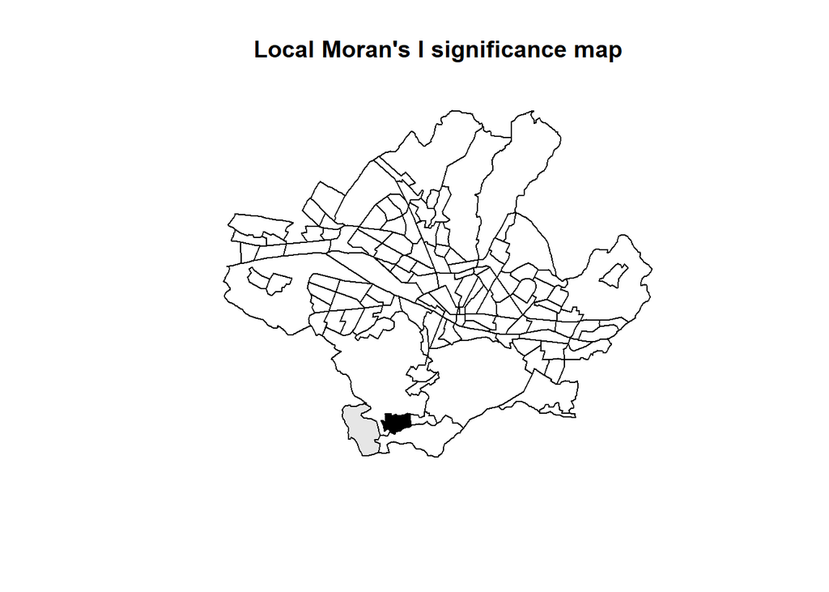

```r
pval <- as.numeric(lmI[,5])
flo$colpval[pval>0.05] <- "white"
flo$colpval[pval<=0.05 & pval>0.01] <- gray(0.9)
flo$colpval[pval<=0.01 & pval>0.001] <- gray(0.7)
flo$colpval[pval<=0.001 & pval>0.0001] <- gray(0.4)
flo$colpval[pval<=0.0001] <- "black"

plot(flo, col=flo$colpval);legend(x=-10, y=73,
                                  legend=c("Not significant",
                                           "p-value = 0.05", "p-value = 0.01", "p-value = 0.001",
                                           "p-value = 0.0001"), fill=c("white", gray(0.9), gray(0.7),
                                                                       gray(0.4), "black"), bty="n",
                                  cex=0.8);title(main="Local Moran's I significance map")
```

As expected most of them are blank, only two seems to form a significant spatial cluster.

# Results

From the analysis it emerges that the variable price is Spatial auto-correlated, but once i apply the Moran’s I test on the OLS residuals of the model, it heavily depends on the Spatial weight matrices, and it does not give any evidence to reject the null hypothesis.

There is no robustness on the output, given that, varying the Spatial weight matrix have a huge impact on the results.

The Monte Carlo approach is the best one to actually see that even the only significant observed variable was in the right tail of the distribution, hence not representative.

The Local analysis is another proof of the lack of significance of Spatial auto-correlation of the spatial units.